# analisisMoRF

Jose Alberto Cabanes Madrid

2024-07-12

```r
library(ggplot2)
library(readr)
library(data.table)
```

# ELF4

Carga de datos de cada uno de los predictores:

```r
ELF4.ANCHOR <- read.delim("C:/Users/josea/OneDrive/Escritorio/Predicciones IDR/ELF4 IUPred2A.txt")

ELF4.MoRFCHIBI <- read.table("C:/Users/josea/OneDrive/Escritorio/Predicciones IDR/ELF4 MoRFCHIBI.txt", quote="\"",
                            col.names = c("POS", "AA", "MORFCHIBI.SCORE", "V4", "V5", "V6", "V7", "V8"))

suppressMessages({
  ELF4.MoRFpred <- as.data.frame(t(read_csv("C:/Users/josea/OneDrive/Escritorio/Predicciones IDR/ELF4 MoRFpred.csv"))[-1,])
names(ELF4.MoRFpred) <- c("IDR", "MORFPRED.SCORE")
})
```

Carga del consenso de regiones desordenadas de analisisIDR.rmd:

```r
ELF4_tramosIDRdf <- readRDS("ELF4_tramosIDR.rds")
```

Agrupación de datos en un solo dataframe:

```r
ELF4.MORF <- data.frame(
  POS = ELF4.ANCHOR$POS,
  ANCHOR.SCORE = ELF4.ANCHOR$ANCHOR.SCORE,
  MORFCHIBI.SCORE = ELF4.MoRFCHIBI$MORFCHIBI.SCORE,
  MORFPRED.SCORE = ELF4.MoRFpred$MORFPRED.SCORE
)
```

Indicar las regiones consideradas MoRF por al menos 1 de los 3 algoritmos de predicción (umbral de 0.5 para ANCHOR y MORFPRED, y de 0.725 para MORFCHIBI):

```r
ELF4.MORF$MORF <- "NO"
ELF4.MORF$conteo_morf <- rowSums(ELF4.MORF[, c("ANCHOR.SCORE", "MORFPRED.SCORE")] >= 0.5)
ELF4.MORF$conteo_morf <- ELF4.MORF$conteo_morf + (ELF4.MORF$MORFCHIBI.SCORE >= 0.725)
ELF4.MORF$MORF[ELF4.MORF$conteo_morf >= 1] <- "SI"
saveRDS(ELF4.MORF, file="ELF4.MORF.rds")
```

Filtrar los residuos MoRF, quedándonos únicamente con aquellos incluidos en las IDR previamente consensuadas:

```r
MoRF_IDR_ELF4 <- subset(ELF4.MORF, MORF == "SI" & POS %in% unlist(Map(`:`, ELF4_tramosIDRdf$inicio, ELF4_tramosIDRdf$fin)))
```

Obtener un listado con las regiones MoRF inicio-fin:

```r
# Convertir a formato data.table
setDT(MoRF_IDR_ELF4)

# Identificar tramos continuos
MoRF_IDR_ELF4[, grp := cumsum(c(1, diff(POS) != 1))]

# Calcular inicio y fin de cada tramo
ELF4_tramosMoRFdf <- MoRF_IDR_ELF4[, .(inicio = min(POS), fin = max(POS)), by = grp]
```

Representación de los MoRF en IDR:

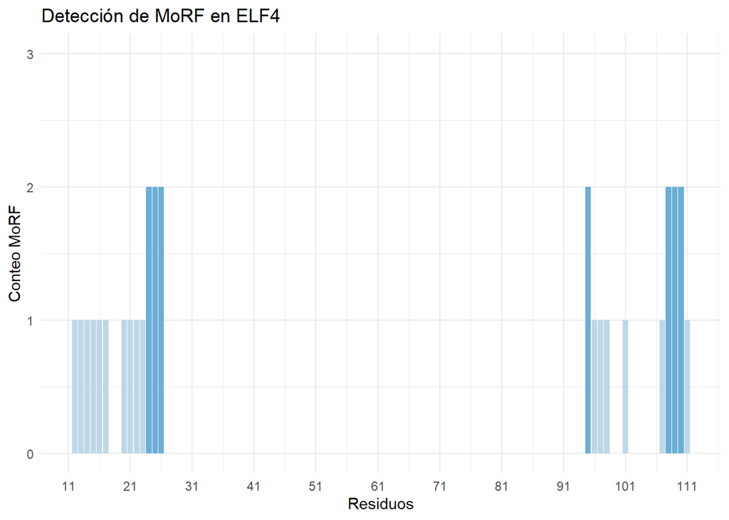

```r
colores <- c("#EFF3FF", "#BDD7E7", "#6BAED6")

# Crear el gráfico de barras
ggplot(MoRF_IDR_ELF4, aes(x = POS, y = conteo_morf)) +
  geom_bar(stat = "identity", fill = colores[MoRF_IDR_ELF4$conteo_morf + 1]) +
  scale_fill_identity() +
  ggtitle("Detección de MoRF en ELF4") +
  labs(x = "Residuos", y = "Conteo MoRF") +
  theme_minimal() +
  scale_x_continuous(breaks = seq(1, 111, by = 10)) +
  scale_y_continuous(limits = c(0, 3), breaks = seq(0, 3, by = 1))
```

Evaluar la relación entre los resultados de los predictores MoRF y las diferencias observadas en el valor pLDDT entre los modelos monomérico y multimérico de AlphaFold a lo largo de la secuencia:

```r
# Carga del archivo de valores de pLDDT en los diferentes modelos de AlphaFold
ELF4_pLDDT <- readRDS("ELF4_pLDDT.rds")

# Fusionar los dataframes por la columna POS
pLDDTvsMORF_ELF4 <- merge(ELF4_pLDDT, ELF4.MORF, by = "POS")

# Ajustar el modelo ANOVA
anova <- aov(difference ~ factor(conteo_morf), data = pLDDTvsMORF_ELF4)

# Verificación de Normalidad de los Residuos
residuos <- residuals(anova)
shapiro_test <- shapiro.test(residuos)
print(shapiro_test)
```

```
##
##  Shapiro-Wilk normality test
##
## data:  residuos
## W = 0.89194, p-value = 1.912e-07
```

Puesto que los datos no siguen una distribución normal (p-valor <0.05 en Shapiro-test), analizaremos la relación entre las variables mediante el método de correlación de Spearman:

```r
correlation <- cor.test(abs(pLDDTvsMORF_ELF4$difference), pLDDTvsMORF_ELF4$conteo_morf, method = "spearman")
print(correlation)
```

```
##
##  Spearman's rank correlation rho
##
## data:  abs(pLDDTvsMORF_ELF4$difference) and pLDDTvsMORF_ELF4$conteo_morf
## S = 336224, p-value = 1.365e-07
## alternative hypothesis: true rho is not equal to 0
## sample estimates:
##        rho
## -0.4751864
```

# LUX

Carga de datos de cada uno de los predictores:

```r
LUX.ANCHOR <- read.delim("C:/Users/josea/OneDrive/Escritorio/Predicciones IDR/LUX IUPred2A.txt")

LUX.MoRFCHIBI <- read.table("C:/Users/josea/OneDrive/Escritorio/Predicciones IDR/LUX MoRFCHIBI.txt", quote="\"",
                            col.names = c("POS", "AA", "MORFCHIBI.SCORE", "V4", "V5", "V6", "V7", "V8"))

suppressMessages({
  LUX.MoRFpred <- as.data.frame(t(read_csv("C:/Users/josea/OneDrive/Escritorio/Predicciones IDR/LUX MoRFpred.csv"))[-1,])
names(LUX.MoRFpred) <- c("IDR", "MORFPRED.SCORE")
})
```

Carga del consenso de regiones desordenadas de analisisIDR.rmd:

```r
LUX_tramosIDRdf <- readRDS("LUX_tramosIDR.rds")
```

Agrupación de datos en un solo dataframe:

```r
LUX.MORF <- data.frame(
  POS = LUX.ANCHOR$POS,
  ANCHOR.SCORE = LUX.ANCHOR$ANCHOR.SCORE,
  MORFCHIBI.SCORE = LUX.MoRFCHIBI$MORFCHIBI.SCORE,
  MORFPRED.SCORE = LUX.MoRFpred$MORFPRED.SCORE
)
```

Indicar las regiones consideradas MoRF por al menos 1 de los 3 algoritmos de predicción (umbral de 0.5 para ANCHOR y MORFPRED, y de 0.725 para MORFCHIBI):

```r
LUX.MORF$MORF <- "NO"
LUX.MORF$conteo_morf <- rowSums(LUX.MORF[, c("ANCHOR.SCORE", "MORFPRED.SCORE")] >= 0.5)
LUX.MORF$conteo_morf <- LUX.MORF$conteo_morf + (LUX.MORF$MORFCHIBI.SCORE >= 0.725)
LUX.MORF$MORF[LUX.MORF$conteo_morf >= 1] <- "SI"
saveRDS(LUX.MORF, file="LUX.MORF.rds")
```

Filtrar los residuos MoRF, quedándonos únicamente con aquellos incluidos en las IDR previamente consensuadas:

```r
MoRF_IDR_LUX <- subset(LUX.MORF, MORF == "SI" & POS %in% unlist(Map(`:`, LUX_tramosIDRdf$inicio, LUX_tramosIDRdf$fin)))
```

Obtener un listado con las regiones MoRF inicio-fin:

```r
# Convertir a formato data.table
setDT(MoRF_IDR_LUX)

# Identificar tramos continuos
MoRF_IDR_LUX[, grp := cumsum(c(1, diff(POS) != 1))]

# Calcular inicio y fin de cada tramo
LUX_tramosMoRFdf <- MoRF_IDR_LUX[, .(inicio = min(POS), fin = max(POS)), by = grp]
```

Representación de los MoRF en IDR:

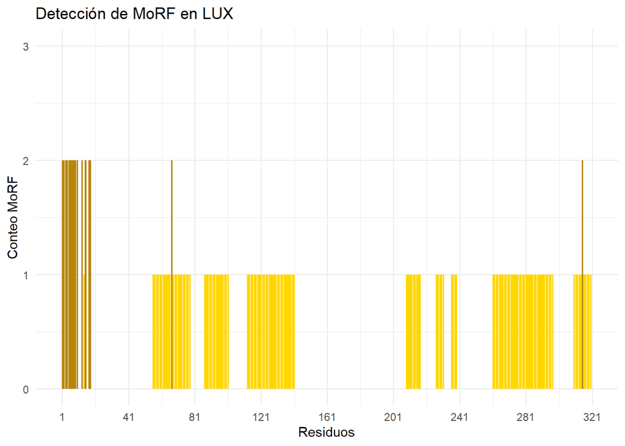

```r
colores <- c("#FFFFCC", "#FFD700", "#B8860B")

# Crear el gráfico de barras
ggplot(MoRF_IDR_LUX, aes(x = POS, y = conteo_morf)) +
  geom_bar(stat = "identity", fill = colores[MoRF_IDR_LUX$conteo_morf + 1]) +
  scale_fill_identity() +
  ggtitle("Detección de MoRF en LUX") +
  labs(x = "Residuos", y = "Conteo MoRF") +
  theme_minimal() +
  scale_x_continuous(breaks = seq(1, 323, by = 40)) +
  scale_y_continuous(limits = c(0, 3), breaks = seq(0, 3, by = 1))
```

Evaluar la relación entre los resultados de los predictores MoRF y las diferencias observadas en el valor pLDDT entre los modelos monomérico y multimérico de AlphaFold a lo largo de la secuencia:

```r
# Carga del archivo de valores de pLDDT en los diferentes modelos de AlphaFold
LUX_pLDDT <- readRDS("LUX_pLDDT.rds")

# Fusionar los dataframes por la columna POS
pLDDTvsMORF_LUX <- merge(LUX_pLDDT, LUX.MORF, by = "POS")

# Ajustar el modelo ANOVA
anova <- aov(difference ~ factor(conteo_morf), data = pLDDTvsMORF_LUX)

# Verificación de Normalidad de los Residuos
residuos <- residuals(anova)
shapiro_test <- shapiro.test(residuos)
print(shapiro_test)
```

```
##
##  Shapiro-Wilk normality test
##
## data:  residuos
## W = 0.97262, p-value = 8.219e-06
```

Puesto que los datos no siguen una distribución normal (p-valor <0.05 en Shapiro-test), analizaremos la relación entre las variables mediante el método de correlación de Spearman:

```r
correlation <- cor.test(abs(pLDDTvsMORF_LUX$difference), pLDDTvsMORF_LUX$conteo_morf, method = "spearman")
print(correlation)
```

```
##
##  Spearman's rank correlation rho
##
## data:  abs(pLDDTvsMORF_LUX$difference) and pLDDTvsMORF_LUX$conteo_morf
## S = 3903568, p-value = 2.227e-08
## alternative hypothesis: true rho is not equal to 0
## sample estimates:
##       rho
## 0.3049604
```

# ELF3

Carga de datos de cada uno de los predictores:

```r
ELF3.ANCHOR <- read.delim("C:/Users/josea/OneDrive/Escritorio/Predicciones IDR/ELF3 IUPred2A.txt")

ELF3.MoRFCHIBI <- read.table("C:/Users/josea/OneDrive/Escritorio/Predicciones IDR/ELF3 MoRFCHIBI.txt", quote="\"",
                            col.names = c("POS", "AA", "MORFCHIBI.SCORE", "V4", "V5", "V6", "V7", "V8"))

suppressMessages({
  ELF3.MoRFpred <- as.data.frame(t(read_csv("C:/Users/josea/OneDrive/Escritorio/Predicciones IDR/ELF3 MoRFpred.csv"))[-1,])
names(ELF3.MoRFpred) <- c("IDR", "MORFPRED.SCORE")
})
```

Carga del consenso de regiones desordenadas de analisisIDR.rmd:

```r
ELF3_tramosIDRdf <- readRDS("ELF3_tramosIDR.rds")
```

Agrupación de datos en un solo dataframe:

```r
ELF3.MORF <- data.frame(
  POS = ELF3.ANCHOR$POS,
  ANCHOR.SCORE = ELF3.ANCHOR$ANCHOR.SCORE,
  MORFCHIBI.SCORE = ELF3.MoRFCHIBI$MORFCHIBI.SCORE,
  MORFPRED.SCORE = ELF3.MoRFpred$MORFPRED.SCORE
)
```

Indicar las regiones consideradas MoRF por al menos 1 de los 3 algoritmos de predicción (umbral de 0.5 para ANCHOR y MORFPRED, y de 0.725 para MORFCHIBI):

```r
ELF3.MORF$MORF <- "NO"
ELF3.MORF$conteo_morf <- rowSums(ELF3.MORF[, c("ANCHOR.SCORE", "MORFPRED.SCORE")] >= 0.5)
ELF3.MORF$conteo_morf <- ELF3.MORF$conteo_morf + (ELF3.MORF$MORFCHIBI.SCORE >= 0.725)
ELF3.MORF$MORF[ELF3.MORF$conteo_morf >= 1] <- "SI"
saveRDS(ELF3.MORF, file="ELF3.MORF.rds")
```

Filtrar las regiones MoRF, quedándonos únicamente con aquellas incluidas en las IDR previamente consensuadas:

```r
MoRF_IDR_ELF3 <- subset(ELF3.MORF, MORF == "SI" & POS %in% unlist(Map(`:`, ELF3_tramosIDRdf$inicio, ELF3_tramosIDRdf$fin)))
```

Obtener un listado con las regiones MoRF inicio-fin:

```r
# Convertir a formato data.table
setDT(MoRF_IDR_ELF3)

# Identificar tramos continuos
MoRF_IDR_ELF3[, grp := cumsum(c(1, diff(POS) != 1))]

# Calcular inicio y fin de cada tramo
ELF3_tramosMoRFdf <- MoRF_IDR_ELF3[, .(inicio = min(POS), fin = max(POS)), by = grp]
```

Representación de los MoRF en IDR:

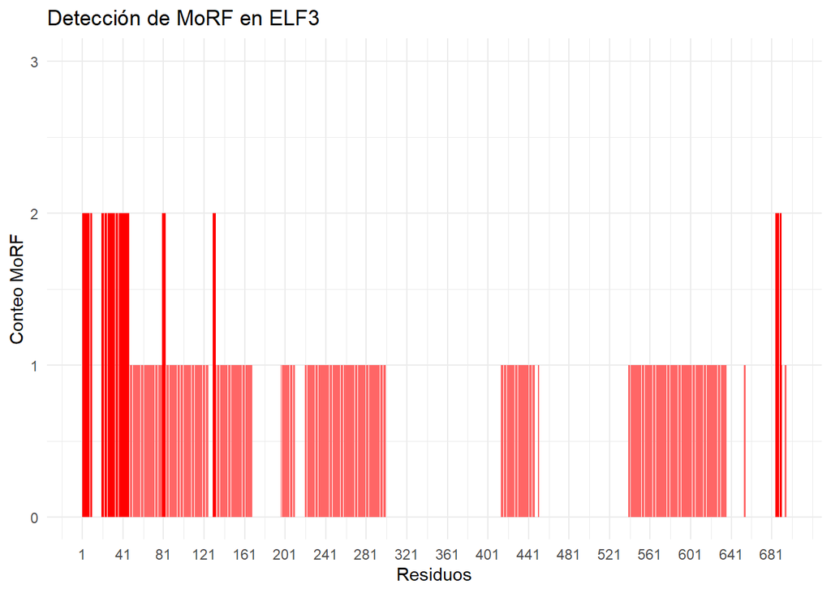

```r
colores <- c("#FFCCCC", "#FF6666", "#FF0000")

# Crear el gráfico de barras
ggplot(MoRF_IDR_ELF3, aes(x = POS, y = conteo_morf)) +
  geom_bar(stat = "identity", fill = colores[MoRF_IDR_ELF3$conteo_morf + 1]) +
  scale_fill_identity() +
  ggtitle("Detección de MoRF en ELF3") +
  labs(x = "Residuos", y = "Conteo MoRF") +
  theme_minimal() +
  scale_x_continuous(breaks = seq(1, 695, by = 40)) +
  scale_y_continuous(limits = c(0, 3), breaks = seq(0, 3, by = 1))
```

Evaluar la relación entre los resultados de los predictores MoRF y las diferencias observadas en el valor pLDDT entre los modelos monomérico y multimérico de AlphaFold a lo largo de la secuencia:

```r
# Carga del archivo de valores de pLDDT en los diferentes modelos de AlphaFold
ELF3_pLDDT <- readRDS("ELF3_pLDDT.rds")

# Fusionar los dataframes por la columna POS
pLDDTvsMORF_ELF3 <- merge(ELF3_pLDDT, ELF3.MORF, by = "POS")

# Ajustar el modelo ANOVA
anova <- aov(difference ~ factor(conteo_morf), data = pLDDTvsMORF_ELF3)

# Verificación de Normalidad de los Residuos
residuos <- residuals(anova)
shapiro_test <- shapiro.test(residuos)
print(shapiro_test)
```

```
##
##  Shapiro-Wilk normality test
##
## data:  residuos
## W = 0.94523, p-value = 2.393e-15
```

Puesto que los datos no siguen una distribución normal (p-valor <0.05 en Shapiro-test), analizaremos la relación entre las variables mediante el método de correlación de Spearman:

```r
correlation <- cor.test(abs(pLDDTvsMORF_ELF3$difference), pLDDTvsMORF_ELF3$conteo_morf, method = "spearman")
print(correlation)
```

```
##
##  Spearman's rank correlation rho
##
## data:  abs(pLDDTvsMORF_ELF3$difference) and pLDDTvsMORF_ELF3$conteo_morf
## S = 49141237, p-value = 0.001307
## alternative hypothesis: true rho is not equal to 0
## sample estimates:
##       rho
## 0.1216981
```